# Lab Assignment footballdata

Elisabeth Linek

## Lab Exercise: Explore Football Data

This dataset containts soccer (or as Europeans prefer: football) player skill ratings (at the time of September 2011). The skill ratings are from the PES Stats Database (PSD), a community-based approach to create a database with accurate statistics and skill ratings for soccer players (originally for the video game “Pro Evolution Soccer” by Konami).

It contains no less than 43 variables on 1851 players from 4 European Leagues (Bundesliga, La Liga, Premier League, Serie A).

## Tasks

1. Visually explore the offensive (Attack) and defensive (Defence) skills of soccer players.

   But before going straight to the code, take a few minutes, think and take notes:
   1. What a priori expectations about the data and possible patterns do you have?
   2. What general exploration strategy would be appropriate?
   3. Which comparisons are possible and interesting?
   4. Which graphical formats would be useful to make these comparisons?
2. Make sure you experiment with
   1. at least three graphical formats as well as
   2. with comparisons *within a single* plot and comparisons *across multiple* plots!

   If you are new to R, have a look at the following two videos on the course site: “surv752-code-05-Adding_Elements_to_an_Exisiting_Plot” “surv752-code-06-Arranging_Multiple_Plots”
3. Finally, try to construct a “bullet graph” as invented by Stephen Few as well as a “slope graph” and “sparklines” as invented by Edward Tufte. (For these latter two graphical formats it’s best to use data with a time component - so you may want to go back to the freedom house data.) For this exercise you my find the lines(), segments() and rect() plotting functions helpful. ___________________________________________

## 1. visual exploration

helpful wrt. positions https://en.wikipedia.org/wiki/Association_football_positions

1. What a priori expectations about the data and possible patterns do you have?
   - Forwards (offencive players) will have likely better offensive skills and defenders defensive players will have rather better defensive skills. Midfeilders will be likely in between depending on their position forward/defence the according skill will be higher (i.e. defensive midfielders (DMF) will have a higher defence skillset whereas offensive (AMF) will have a likely better offensive skillset).
   - Midfielders should have a higher passing accuracy than forwards.
   - Left footed players will play more likeley on the left side in case they don’t play on both sides.
   - The four represented countries in the dataset represent the top four ranked countries in the UEFA association ranking by country of the season 2010-11. The order of the ranking was England, Spain, Italy and Germany at which England was ranked first (not the season ranking!). This could be reflected in the dataset. https://en.wikipedia.org/wiki/2010%E2%80%9311_UEFA_Champions_League https://www.uefa.com/memberassociations/uefarankings/country/season=2010/index.html
2. What general exploration strategy would be appropriate?
   - use the summary function
   - dplyr to group and and filter the data
3. Which comparisons are possible and interesting?
   - Top n teams of the country vs the rest.
   - Player position distribution wrt. total number of players.
   - Avg. height by country
   - dribbling vs passing
   - Nationalities playing soccer in the four countries ->foreign vs. local
   - Attack/Defence wrt. age
4. Which graphical formats would be useful to make these comparisons?
   - since it’s just Attack and Defence to compare it’s maybe best to go with small minimals to get a wider scope

```r
options(tibble.print_max = Inf)
options(Encoding="UTF-8")

# tabelle - die die daten umreisst, überblick verschafft - wieviele spieler je liga?
# erste diagramme

library(dplyr)
library(grDevices)


football_data = read.csv("footballdata.csv")

summary(football_data)
```

```
##        X                      Name                League
##  Min.   :   1.0   Gonzalo Castro:   2   Bundesliga   :434
##  1st Qu.: 463.5   Julio Cesar   :   2   LaLiga       :454
##  Median : 926.0   Marco Rossi   :   2   PremierLeague:496
##  Mean   : 926.0   Paul Robinson :   2   SerieA       :467
##  3rd Qu.:1388.5   Aaron Hughes  :   1
##  Max.   :1851.0   Aaron Hunt    :   1
##                   (Other)       :1841
##                    Team          Number           Position
##  Manchester United FC:  30   Min.   : 0.0   Defender  :592
##  QPR                 :  29   1st Qu.: 7.0   Forward   :411
##  SS Lazio            :  29   Median :15.0   Goalkeeper:191
##  Stoke City FC       :  29   Mean   :17.1   Midfielder:657
##  Arsenal FC          :  28   3rd Qu.:23.0
##  AS Roma             :  28   Max.   :99.0
##  (Other)             :1678
##      Positions            Birthday         Nationality       Age
##  GK!      : 191   (04/08/1985):   4   Spanish    :305   Min.   :17.0
##  CB!      : 176   (11/05/1986):   4   Italian    :239   1st Qu.:23.0
##  CF!      : 146   (14/02/1987):   4   German     :216   Median :26.0
##  CB!, SB  :  95   (14/05/1984):   4   English    :179   Mean   :26.5
##  SB!      :  95   (17/03/1986):   4   Argentinian: 97   3rd Qu.:30.0
##  DMF!, CMF:  68   (Other)     :1794   Brazilian  : 85   Max.   :42.0
##  (Other)  :1080   NA's        :  37   (Other)    :730   NA's   :37
##      Height          Weight       InjuryTolerance Foot     Side
##  Min.   :160.0   Min.   : 55.00   A   :  55       L: 412   B:1402
##  1st Qu.:178.0   1st Qu.: 72.00   B   :1643       R:1439   L: 237
##  Median :183.0   Median : 76.00   C   : 150                R: 212
##  Mean   :182.3   Mean   : 76.67   NA's:   3
##  3rd Qu.:187.0   3rd Qu.: 81.00
##  Max.   :203.0   Max.   :100.00
##
##      Attack         Defence         Balance         Stamina
##  Min.   : 0.00   Min.   : 0.00   Min.   : 0.00   Min.   : 0.00
##  1st Qu.:65.00   1st Qu.:48.00   1st Qu.:78.00   1st Qu.:82.00
##  Median :73.00   Median :67.00   Median :82.00   Median :83.00
##  Mean   :68.33   Mean   :63.51   Mean   :81.53   Mean   :82.08
##  3rd Qu.:77.00   3rd Qu.:78.00   3rd Qu.:85.00   3rd Qu.:85.00
##  Max.   :95.00   Max.   :94.00   Max.   :96.00   Max.   :96.00
##
```

[output cut: 41 more lines]

```
##  Min.   : 0.00   Min.   : 0.0   Min.   :3.000    Min.   :2.000
##  1st Qu.:50.00   1st Qu.:77.0   1st Qu.:6.000    1st Qu.:4.000
##  Median :50.00   Median :78.0   Median :6.000    Median :5.000
##  Mean   :53.33   Mean   :78.8   Mean   :6.143    Mean   :5.063
##  3rd Qu.:50.00   3rd Qu.:81.0   3rd Qu.:7.000    3rd Qu.:6.000
##  Max.   :93.00   Max.   :98.0   Max.   :8.000    Max.   :8.000
##
##  WeakFootFrequency
##  Min.   :2.00
##  1st Qu.:4.00
##  Median :5.00
##  Mean   :4.78
##  3rd Qu.:5.00
##  Max.   :8.00
##
```

```r
football_data %>%
  group_by(Team) %>%
  summarise(meanA = mean(Attack), meanD = mean(Defence), n = n())
```

```
## # A tibble: 78 x 4
##    Team                     meanA meanD     n
##    <fct>                    <dbl> <dbl> <int>
##  1 1. FC Kaiserslautern      68.7  59.8    25
##  2 1. FC Köln                68.4  63.3    24
##  3 1. FC Nürnberg            67.2  63.7    21
##  4 1. FSV Mainz 05           69.2  60.2    26
##  5 AC Cesena                 69.8  60.8    18
##  6 AC Chievo Verona          65.2  66.5    23
##  7 AC Milan                  69.4  67.5    27
##  8 AC Siena                  70.1  61.9    23
##  9 ACF Fiorentina            69.8  62.7    25
## 10 Arsenal FC                67.4  64.3    28
## 11 AS Roma                   69.5  64.0    28
## 12 Aston Villa FC            67.1  65.0    22
```

[output cut: 66 more lines]

```r
football_data %>%
  group_by(Nationality) %>%
  summarise(n = n())
```

```
## # A tibble: 86 x 2
##    Nationality        n
##    <fct>          <int>
##  1 Albanian           5
##  2 Algerian           8
##  3 American          12
##  4 Argentinian       97
##  5 Australian         6
##  6 Austrian          15
##  7 Barbadian          1
##  8 Belarusian         2
##  9 Belgian           18
## 10 Benin              1
## 11 Bosnian           10
## 12 Brazilian         85
```

[output cut: 74 more lines]

```r
overall_avg <- football_data %>%
  summarise(meanA = mean(Attack), meanD = mean(Defence), sdA = sd(Attack), sdD = sd(Defence))
overall_avg
```

```
##      meanA    meanD      sdA      sdD
## 1 68.33009 63.50945 14.65151 15.86055
```

```r
pos_avg <- football_data %>%
  group_by(Position) %>%
  summarise(meanA = mean(Attack), meanD = mean(Defence), n = n()) %>%
  arrange(meanA, meanD)
pos_avg
```

```
## # A tibble: 4 x 4
##   Position   meanA meanD     n
##   <fct>      <dbl> <dbl> <int>
## 1 Goalkeeper  30.3  82.6   191
## 2 Defender    66.3  75.1   592
## 3 Midfielder  73.7  61.2   657
## 4 Forward     80.4  41.6   411
```

## 2. experimental approximation

```r
ad_by_age <- football_data %>%
  filter(!is.na(Age)) %>%
  group_by(Age, Position) %>%
  summarise(meanA = mean(Attack), meanD = mean(Defence), n = n()) %>%
  arrange(Age, meanA, meanD)

min_age <- ad_by_age$Age %>% min
max_age <- ad_by_age$Age %>% max

min_ma <- ad_by_age$meanA %>% min
max_ma <- ad_by_age$meanA %>% max

print('mean Attack and Defence by Age')
```

```
## [1] "mean Attack and Defence by Age"
```

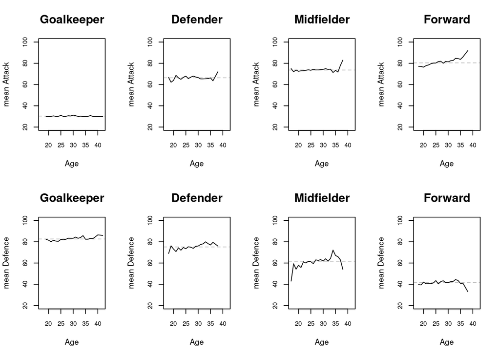

```r
par(mfrow=c(2, 4))
for(i in pos_avg$Position){
  plot(ad_by_age$Age[ad_by_age$Position == i],
       ad_by_age$meanA[ad_by_age$Position == i],
       type='l',
       xlim=c(min_age, max_age),
       ylim=c(20,100),
       cex.main=1.5, cex.lab=1, cex.axis=.8,
       main=i,
       xlab='Age', ylab='mean Attack',
       panel.first=c(abline(h=pos_avg$meanA[pos_avg$Position == i], lty=2, col="grey")))
}
for(i in pos_avg$Position){
  plot(ad_by_age$Age[ad_by_age$Position == i],
       ad_by_age$meanD[ad_by_age$Position == i],
       type='l',
       xlim=c(min_age, max_age),
       ylim=c(20,100),
       cex.main=1.5, cex.lab=1, cex.axis=.8,
       main=i,
       xlab='Age', ylab='mean Defence',
       panel.first=c(abline(h=pos_avg$meanD[pos_avg$Position == i], lty=2, col="grey")))
}
```

```r
colors <- c('red', 'yellow', 'blue', 'green')
leagues <- football_data$League %>% unique %>% sort
league_color_map <- setNames(as.list(colors), leagues)
league_color_map
```

```
## $Bundesliga
## [1] "red"
##
## $LaLiga
## [1] "yellow"
##
## $PremierLeague
## [1] "blue"
##
## $SerieA
## [1] "green"
```

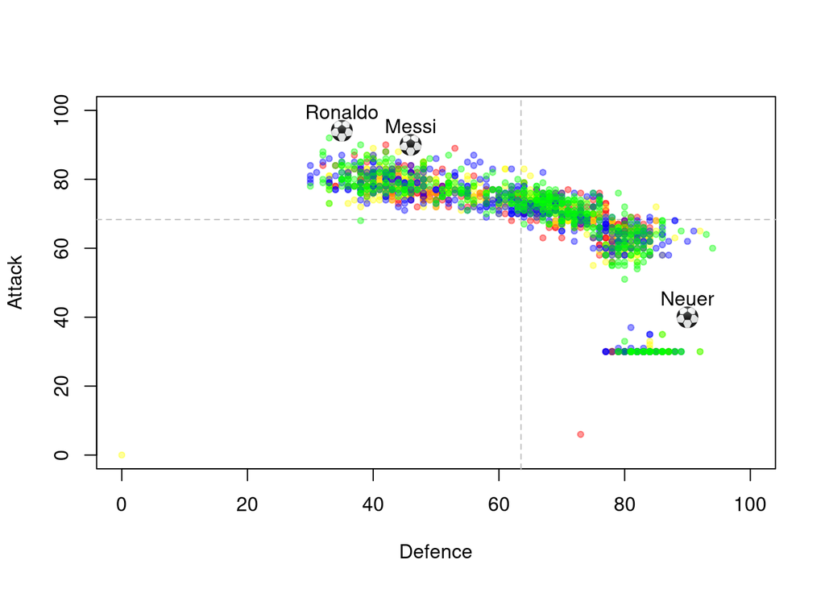

```r
par(mfrow=c(1, 1))
plot(NULL, xlim=c(0,100), ylim=c(0,100),
       xlab='Defence', ylab='Attack')
abline(h=overall_avg$meanA, lty=2, col="grey")
abline(v=overall_avg$meanD, lty=2, col="grey")
for (i in leagues) {
  points(football_data$Defence[football_data$League == i], football_data$Attack[football_data$League == i],
       pch=20,
       col=adjustcolor(league_color_map[[i]], alpha.f = 0.4))
}

# https://www.w3schools.com/charsets/ref_utf_symbols.asp
neuer <- c(football_data$Defence[football_data$Name == "Manuel Neuer"],
       football_data$Attack[football_data$Name == "Manuel Neuer"])
points(neuer[1], neuer[2], pch="⚽")
text(neuer[1], neuer[2], labels="Neuer", pos=3)

ronaldo <- c(football_data$Defence[football_data$Name == "Cristiano Ronaldo"],
       football_data$Attack[football_data$Name == "Cristiano Ronaldo"])
points(ronaldo[1], ronaldo[2], pch="⚽")
text(ronaldo[1], ronaldo[2], labels="Ronaldo", pos=3)

messi <- c(football_data$Defence[football_data$Name == "Leo Messi"],
       football_data$Attack[football_data$Name == "Leo Messi"])
points(messi[1], messi[2], pch="⚽")
text(messi[1], messi[2], labels="Messi", pos=3)
```

```r
leagues <- c('Bundesliga', 'LaLiga', 'PremierLeague', 'SerieA')
nationality <- list('German', 'Spanish', list('English', 'Welsh'), 'Italian')
positions <- c("GK", "D", "M", "F")

national_player <- function(i) {
  return (football_data %>%
    filter(League == leagues[i], Nationality %in% nationality[[i]]) %>%
    group_by(Position) %>%
    summarise(meanA = mean(Attack), meanD = mean(Defence), n = n()) %>%
    arrange(meanA, meanD))
}

foreign_player <- function(i) {
  return (football_data %>%
    filter(League == leagues[i], !Nationality %in% nationality[[i]]) %>%
    group_by(Position) %>%
    summarise(meanA = mean(Attack), meanD = mean(Defence), n = n()) %>%
    arrange(meanA, meanD))
}

#inland
par(mfrow=c(2, 4))
for (i in 1:4)  {
  natp <- national_player(i)
  natp$Position <- factor(natp$Position, levels(natp$Position)[c(3, 1, 4, 2)])
  print(natp)
  forp <- foreign_player(i)
  forp$Position <- factor(forp$Position, levels(forp$Position)[c(3, 1, 4, 2)])
  plot(0, 0, xlim=c(1,4), ylim=c(20, 100), xaxt="n", main=leagues[i], xlab="Position", ylab="Attack")
  axis(1, at=1:4, labels=positions)
  points(natp$Position, natp$meanA, type="p", pch=20, col="red")
  points(forp$Position, forp$meanA, type="p", pch=20, col="blue")
}
```

```
## # A tibble: 4 x 4
##   Position   meanA meanD     n
##   <fct>      <dbl> <dbl> <int>
## 1 Goalkeeper  30.3  81.9    39
## 2 Defender    66.6  74.4    60
## 3 Midfielder  74.0  58.8    82
## 4 Forward     80.0  41.7    26
```

```
## # A tibble: 4 x 4
##   Position   meanA meanD     n
##   <fct>      <dbl> <dbl> <int>
## 1 Goalkeeper  30.2  82.2    35
## 2 Defender    65.8  73.4    92
## 3 Midfielder  73.9  59.5   108
## 4 Forward     80.2  41.8    41
```

```
## # A tibble: 4 x 4
##   Position   meanA meanD     n
##   <fct>      <dbl> <dbl> <int>
## 1 Goalkeeper  30.1  80.9    14
## 2 Defender    65.7  75.6    68
## 3 Midfielder  73.0  61.8    77
## 4 Forward     80.2  40.8    38
```

```
## # A tibble: 4 x 4
##   Position   meanA meanD     n
##   <fct>      <dbl> <dbl> <int>
## 1 Goalkeeper  30.0  83.8    27
## 2 Defender    66.0  75.6    82
## 3 Midfielder  73.7  65.0    67
## 4 Forward     81.1  40.6    53
```

```
## # A tibble: 4 x 4
##   Position   meanA meanD     n
##   <fct>      <dbl> <dbl> <int>
## 1 Goalkeeper  30.3  81.9    39
## 2 Defender    66.6  74.4    60
## 3 Midfielder  74.0  58.8    82
## 4 Forward     80.0  41.7    26
```

```
## # A tibble: 4 x 4
##   Position   meanA meanD     n
##   <fct>      <dbl> <dbl> <int>
## 1 Goalkeeper  30.2  82.2    35
## 2 Defender    65.8  73.4    92
## 3 Midfielder  73.9  59.5   108
## 4 Forward     80.2  41.8    41
```

```
## # A tibble: 4 x 4
##   Position   meanA meanD     n
##   <fct>      <dbl> <dbl> <int>
## 1 Goalkeeper  30.1  80.9    14
## 2 Defender    65.7  75.6    68
## 3 Midfielder  73.0  61.8    77
## 4 Forward     80.2  40.8    38
```

```
## # A tibble: 4 x 4
##   Position   meanA meanD     n
##   <fct>      <dbl> <dbl> <int>
## 1 Goalkeeper  30.0  83.8    27
## 2 Defender    66.0  75.6    82
## 3 Midfielder  73.7  65.0    67
## 4 Forward     81.1  40.6    53
```

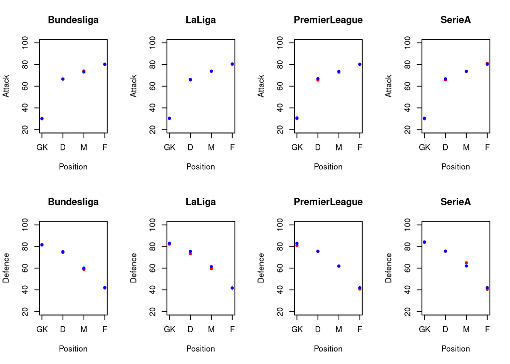

```r
for (i in 1:4)  {
  natp <- national_player(i)
  natp$Position <- factor(natp$Position, levels(natp$Position)[c(3, 1, 4, 2)])
  print(natp)
  forp <- foreign_player(i)
  forp$Position <- factor(forp$Position, levels(forp$Position)[c(3, 1, 4, 2)])
  plot(0, 0, xlim=c(1,4), ylim=c(20, 100), xaxt="n", main=leagues[i], xlab="Position", ylab="Defence")
  axis(1, at=1:4, labels=positions)
  points(natp$Position, natp$meanD, type="p", pch=20, col="red")
  points(forp$Position, forp$meanD, type="p", pch=20, col="blue")
}
```

## 3. bullet graph and slope graph

http://motioninsocial.com/tufte/ https://github.com/leeper/slopegraph

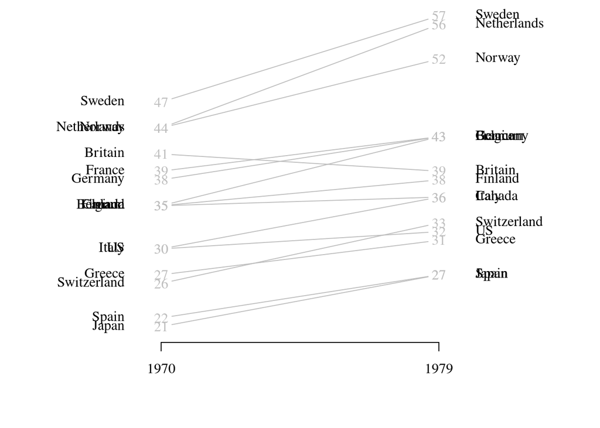

```r
library("slopegraph")
data(gdp)
slopegraph(gdp, col.lines = 'gray', col.lab = "black",
           xlabels = c('1970', '1979'))
```

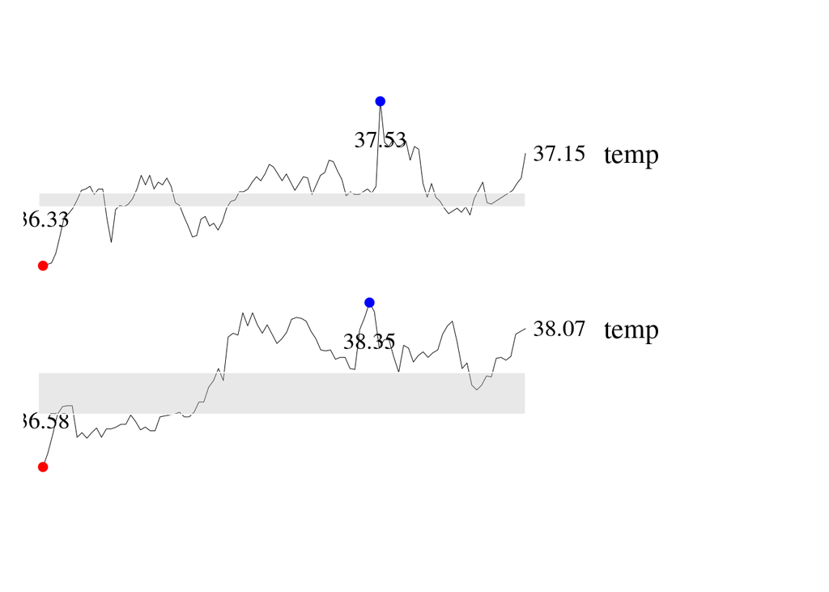

```r
par(mfrow=c(2,1), mar=c(1,0,0,8), oma=c(4,1,4,4))
sparklines <- function(d, i) {
  plot(d[,i], lwd=0.5, axes=F, ylab="", xlab="", main="", type="l", new=F)
  axis(4, at=d[nrow(d),i], labels=d[nrow(d),i], tick=F, las=1, line=-1.5,
       family="serif", cex.axis=1.2)
  axis(4, at=d[nrow(d),i], labels=names(d[i]), tick=F, line=1.5,
       family="serif", cex.axis=1.4, las=1)
  text(which.max(d[,i]), max(d[,i]), labels=max(d[,i]),
       family="serif", cex=1.2, adj=c(0.5,3))
  text(which.min(d[,i]), min(d[,i]), labels=min(d[,i]),
       family="serif", cex=1.2, adj=c(0.5,-2.5))
  ymin <- min(d[,i])
  tmin <- which.min(d[,i])
  ymax<-max(d[,i])
  tmax<-which.max(d[,i])
  points(x=c(tmin,tmax), y=c(ymin,ymax), pch=19, col=c("red","blue"), cex=1)
  rect(0, summary(d[,i])[2], nrow(d), summary(d[,i])[4], border=0,
       col = rgb(190, 190, 190, alpha=90, maxColorValue=255))
}
sparklines(beaver1, 3)
sparklines(beaver2, 3)
```

```r
library(ggplot2)

bullet.graph <- function(bg.data){

  # compute max and half for the ticks and labels
  max.bg <- max(bg.data$high)
  mid.bg <- max.bg / 2

  gg <- ggplot(bg.data)
  gg <- gg + geom_bar(aes(measure, high),  fill="goldenrod2", stat="identity", width=0.5, alpha=0.2)
  gg <- gg + geom_bar(aes(measure, mean),  fill="goldenrod3", stat="identity", width=0.5, alpha=0.2)
  gg <- gg + geom_bar(aes(measure, low),   fill="goldenrod4", stat="identity", width=0.5, alpha=0.2)
  gg <- gg + geom_bar(aes(measure, value), fill="black",  stat="identity", width=0.2)
  gg <- gg + geom_errorbar(aes(y=target, x=measure, ymin=target, ymax=target), color="red", width=0.45)
  gg <- gg + geom_point(aes(measure, target), colour="red", size=5)
  gg <- gg + scale_y_continuous(breaks=seq(0,max.bg,mid.bg))
  gg <- gg + coord_flip()
  gg <- gg + theme(axis.text.x=element_text(size=17),
                   axis.title.x=element_blank(),
                   axis.line.y=element_blank(),
                   axis.text.y=element_text(hjust=1, color="black"),
                   axis.ticks.y=element_blank(),
                   axis.title.y=element_blank(),
                   legend.position="none",
                   panel.background=element_blank(),
                   panel.border=element_blank(),
                   panel.grid.major=element_blank(),
                   panel.grid.minor=element_blank(),
                   plot.background=element_blank())

  return(gg)
}

fdf <- football_data %>%
  group_by(Team) %>%
  summarise(meanA = mean(Attack), meanD = mean(Defence), n = n())
fdf
```

```
## # A tibble: 78 x 4
##    Team                     meanA meanD     n
##    <fct>                    <dbl> <dbl> <int>
##  1 1. FC Kaiserslautern      68.7  59.8    25
##  2 1. FC Köln                68.4  63.3    24
##  3 1. FC Nürnberg            67.2  63.7    21
##  4 1. FSV Mainz 05           69.2  60.2    26
##  5 AC Cesena                 69.8  60.8    18
##  6 AC Chievo Verona          65.2  66.5    23
##  7 AC Milan                  69.4  67.5    27
##  8 AC Siena                  70.1  61.9    23
##  9 ACF Fiorentina            69.8  62.7    25
## 10 Arsenal FC                67.4  64.3    28
## 11 AS Roma                   69.5  64.0    28
## 12 Aston Villa FC            67.1  65.0    22
```

[output cut: 66 more lines]

```r
mean(fdf$meanA)
```

```
## [1] 68.33069
```

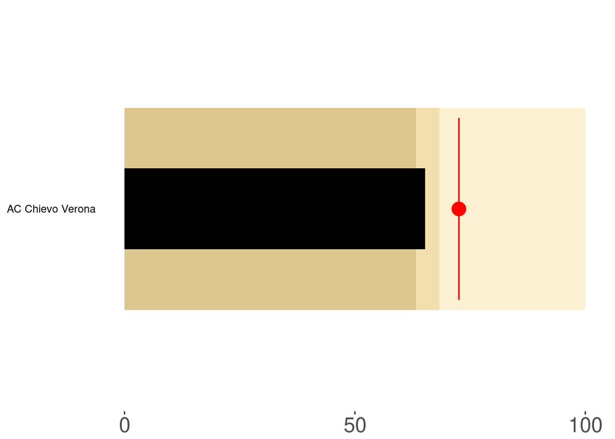

```r
df <- data.frame(
  measure=c("AC Chievo Verona"),
  high=c(100),
  mean=c(mean(football_data$Attack)),
  low=c(min(fdf$meanA)),
  target=c(max(fdf$meanA)),
  value=c(fdf$meanA[fdf$Team=="AC Chievo Verona"])
)

plot(bullet.graph(df))
```

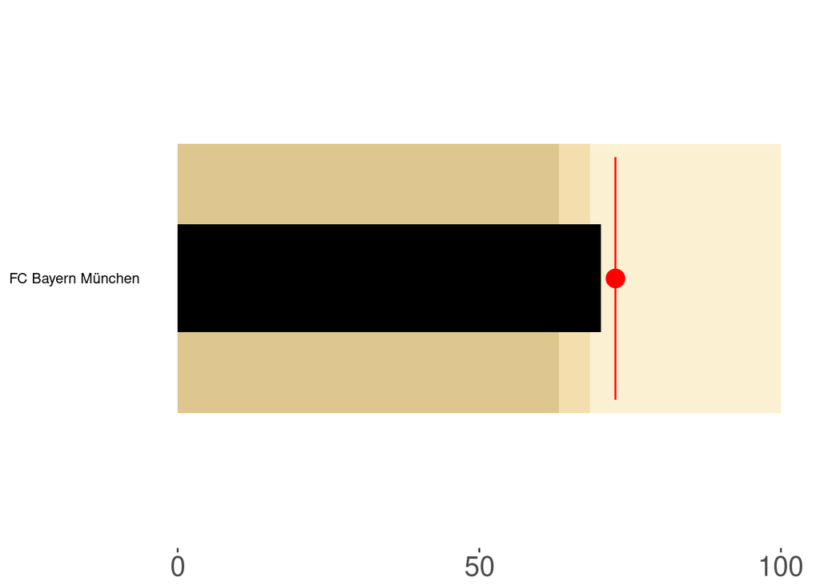

```r
df <- data.frame(
  measure=c("FC Bayern München"),
  high=c(100),
  mean=c(mean(football_data$Attack)),
  low=c(min(fdf$meanA)),
  target=c(max(fdf$meanA)),
  value=c(fdf$meanA[fdf$Team=="FC Bayern München"])
)

plot(bullet.graph(df))
```

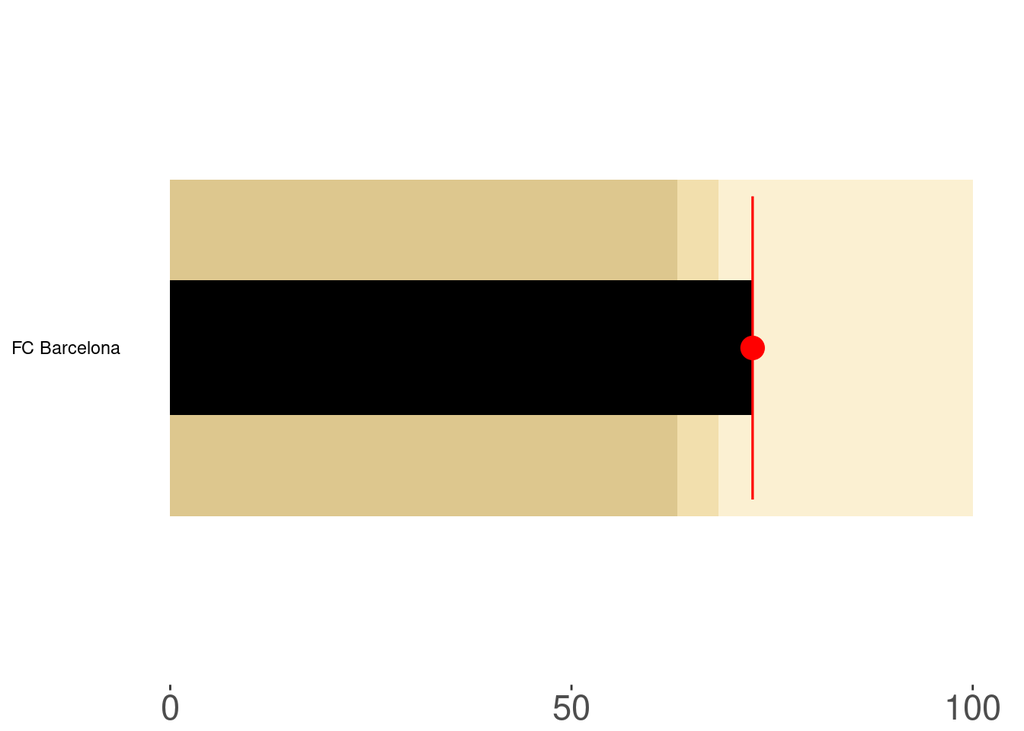

```r
df <- data.frame(
  measure=c("FC Barcelona"),
  high=c(100),
  mean=c(mean(football_data$Attack)),
  low=c(min(fdf$meanA)),
  target=c(max(fdf$meanA)),
  value=c(fdf$meanA[fdf$Team=="FC Barcelona"])
)

plot(bullet.graph(df))
```